# A4: Incarceration

### Introduction

The United States has the highest incarceration rate in the world. This issue is compounded by significant racial disparities, with Black Americans incarcerated at disproportionately high rates due to systemic racism. Understanding these trends is crucial for developing informed policies and address the inequalities. This report uses data from the Vera Institute to analyze incarceration trends over time, focusing on variables such as total jail population and racial demographics by visualizing it on different types charts. I plan on analyzing black jail population, total jail population, white jail population, etc. to bring out the disparities.

### Summary Information

```
## $avg_total_jail_pop_2018
## [1] 248.945
##
## $county_with_max_jail_pop_2018
## [1] "Los Angeles County"
##
## $max_jail_pop_2018
## [1] 17208
##
## $avg_black_jail_pop_2018_value
## [1] 83.57426
##
## $black_percentage_increase
## [1] 44.64293
##
## $white_percentage_increase
## [1] 108.2094
##
## $male_to_female_ratio_2018
## [1] 5.972268
```

The summary majorly uses 2018 data as it is the most recent year in the dataset. I used dplyr to find the average jail population, county with the highest jail population(LA county) and the maximum population in 2018. Since this project is about finding race related data, I calculated that more than 1/3 of the total jail population (~33.6%) comprised of black individuals in 2018 in the US. I also found that the number of black individuals in jail has increased by 44.6% from 1990 to 2018, while the number of white individuals has increased by 108.2%. I even found that there are approx 6 times more males than females.

### The Dataset

Who collected the data?

- Collected by Vera Institute, the data has made neat and posted on GitHub by Melanie Walsh

How was the data collected or generated?

- This data was collected by Vera institute from two Bureau of Justice Statistics (BJS) data collections: the Census of Jails (COJ), which covers all jails and is conducted every five to eight years since 1970, and the Annual Survey of Jails (ASJ), which covers about one-third of jails-and includes nearly all of the largest jails-that has been conducted in non-census years since 1982.The data was also gathered from other sources like state and county records. Melanie Walsh split the datasets to make it smaller and more accessible.

Why was the data collected?

- The dataset was collected by the Vera Institute as part of their initiative to track incarceration trends in the United States. Melanie Walsh split the datasets to make it smaller and more accessible.

How many observations (rows) are in your data?

- 153811 observations

How many features (columns) are in the data?

- 28 variables

What, if any, ethical questions or questions of power do you need to consider when working with this data?  
- One of the ethical consideration is the potential for reinforcing stereotypes when analyzing the data. It is important to use the data to promote equity and justice. - Due to the large time frame that the data was collected, how do we ensure the same or similar data collection strategies were used throughout? - Since this data has been collected from other sources and databases several times, how can we make sure that the collector was not biased?

What are possible limitations or problems with this data? (at least 200 words)

- The dataset has got a lot of NA values(blank spaces). This reduces the statistical power and can misrepresent a population. Missing data can introduce bias, especially if the missingness is not random. If certain types of data are more likely to be missing, the results may not accurately reflect the truth.
- In addition, the data collected is the number of individuals in jail is calculated over the course of a year rather than collecting exact data per month. This can cause problems with exact data values and reliability. Fluctuations in the jail population are not visible in this data set which can be significant in analyzing. I believe this population was calculated by taking a mean which can hide significant data or even outliers are ignored. Relying entirely on yearly averages can hide important trends and variations that occur throughout the year. For example, crime rates increase during certain seasons, policy changes, etc.
- The data only includes 2 genders which shows the collecting bias. The data also does not include mixed race individuals which again results in a lack of representation and potential bias when collecting. The absence of these categories means that the dataset fails to capture the full diversity of the jail population, which is crucial for understanding and analyzing the trends.

### Trends Over Time Chart

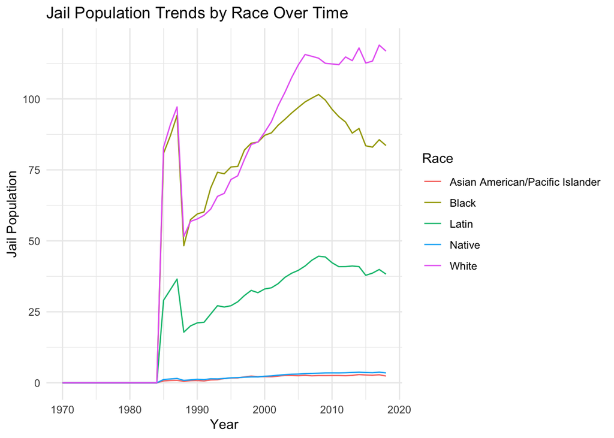

### Variable Comparison Chart

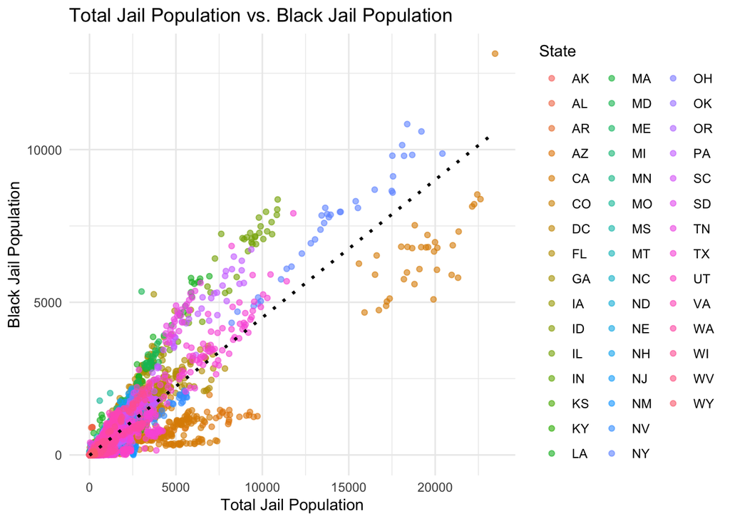

This chart is a scatterplot that finds an assosciation between the Total Jail population and Black jail population. A dotted black trend line is included to indicate the overall trend in the data. This helps viewers quickly assess the general relationship between the total jail population and the Black jail population. The chart visually demonstrates the relationship between two continuous variables (The population in this dataset is a continuous variable). It also allows for the identification of disparities in incarceration rates among different states. I specifically chose the black community to highlight disparities and since they are have one of the highest jail population. States with points far above the trend line have disproportionately high Black jail populations compared to their total jail populations, which indicates potential issues of racial disparity and bias in the criminal justice system. The comparison by states can also help identify which states have a high disparity. The graph clearly shows a positive association in Total Jail population and Black Jail population i.e., with an increase in Total Jail Population there is an increase in Black Jail Population. Policymakers can use this chart to see the broader impact of incarceration policies and their disproportionate effects on Black populations.

### Map

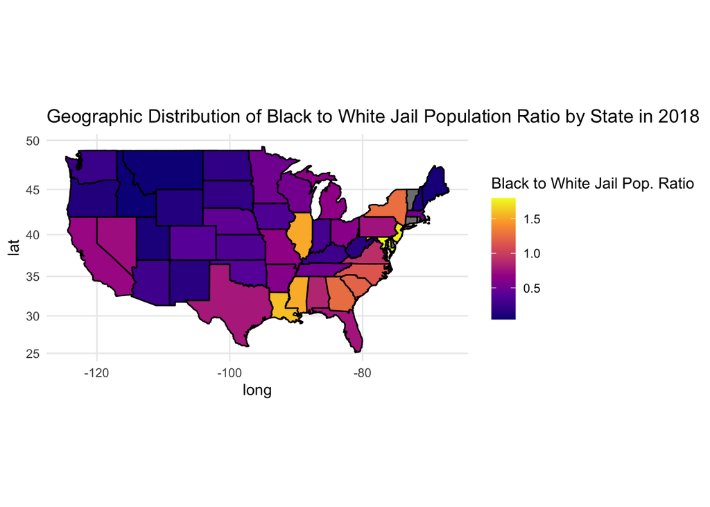

The map visualizes the ratio of Black to White jail populations by state in the United States for the year 2018. This map is significant as it helps to illustrate racial disparities in the US criminal justice system across different states by visualizing it on the map itself. The map highlights the differences in incarceration rates between Black and White populations where some states have a surprisingly higher ratio. A ratio greater than 1 indicates more Black Jail population than the White Jail population. The eastern states, particularly in the Southeast and Mid-Atlantic regions, tend to have higher Black to White jail population ratios while western and north western states have lower ratios. This indicates disparities which may vary geographically because of regional policies, socio-economic factors, and historical contexts. This can again help local policy maker create equitable policies.